# PSTAT 174/274 Spring 2023: Homework 5

Dylan Berneman

2023-05-24

*Note: {Z<sub>t</sub>} ∼ WN(0, σ<sub>Z</sub><sup>2</sup>) denotes white noise.*

### Question 1

Create a glossary of R-commands for time series. It should contain all commands that you learned so far in the labs, doing homework, and reviewing posted lecture slides. At the minimum, the glossary should include commands that allow:

- define working directory
- read and plot data
- simulate and plot ARMA models
- add trend and mean line to the original time series plot
- calculate and plot theoretical acf/pacf for ARMA models
- calculate and plot sample acf/pacf
- check whether a particular model is causal/invertible (R commands to find and plot roots of polynomials)
- perform Box-Cox transforms
- perform differencing data at lags 1 and 12
- perform Yule-Walker estimation and find standard deviations of the estimates
- perform MLE and check AICC associated with the model

#### Packages

**`astsa`**

- *Applied Statistical Time Series Analysis*

**`tsdl`**

- *devtools::install_github(“FinYang/tsdl”)*
- *Library and practice with time series models*

**`distributional`**

- *Vectorised distribution objects with tools for manipulating, visualizing, and using probability distributions. Designed to allow model prediction outputs to return distributions rather than their parameters, allowing users to directly interact with predictive distributions in a data-oriented workflow.*

**`FinTS`**

- *Plot the theoretical ACF corresponding to an ARMA model*

**`FitARMA`**

- *implements fast maximum likelihood algorithm for fitting ARMA time series*

**`forecast`**

- *Methods and tools for displaying and analysing univariate time series forecasts including exponential smoothing via state space models and automatic ARIMA modelling.*

**`latex2exp`**

- *Use LaTeX Expressions in Plots*

**`polynom`**

- *A Collection of Functions to Implement a Class for Univariate Polynomial Manipulations*

**`readr`**

- *Read in data*

**`sarima`**

- *Functions, classes and methods for time series modelling with ARIMA and related models.*

**`tinytex`**

- *Helper Functions to Install and Maintain TeX Live, and Compile LaTeX Documents*

```r
library(devtools)
# install.packages('astsa')
# install.packages('basicTrendline')
# install.packages('distributional')
# install.packages('FinTS')
# install.packages('FitARMA')
# install.packages("forecast")
# install.packages('ggplot2')
# install.packages('latex2exp')
# install.packages('polynom')
# install.packages('sarima')
install.packages("MuMIn")
library(MuMIn)
library(astsa)
library(basicTrendline)
devtools::install_github("FinYang/tsdl")
library(tsdl)
library(distributional)
library(dplyr)
library(FinTS)
library(FitARMA)
library(forecast)
library(ggplot2)
library(latex2exp)
library(MASS)
library(polynom)
library(readr)
library(readxl)
library(sarima)
library(tinytex)
```

#### Read and Plot Data

read.csv(file = , header)

- *`Read` in data (file must be in the same working directory)*

ts(data = ” “, start = numeric(0), end = numeric(0), frequency = numeric(0))

- *`data` must be a vector, matrix, or data frame*
- *`start` is the time of the 1<sup>st</sup> observation*
- *`frequency` is the number of observations per unit of time*

plot(x, y, xlab = “…”, ylab = “…”, xlim = c( ), ylim = c( ), main = TeX( ), col = “…”)

- *`TeX(r'(...$ code $...)')` Render text w/ latex code in place of a string*
- *`xlab` changes the x-axis label*
- *`ylab` changes the y-axis label*
- *`xlim` specify the values on the x-axis*
- *`ylim` specify the values on the y-axis*
- *`main` changes the title of the plot*
- *`col` changes the color of the line*
- *can also use `plot.ts()` or `ts.plot()`*

```r
# read in data
uspop = read.csv("uspop.txt", header=FALSE)
head(uspop, 5)
```

```
##         V1
## 1  3929214
## 2  5308483
## 3  7239881
## 4  9638453
## 5 12860702
```

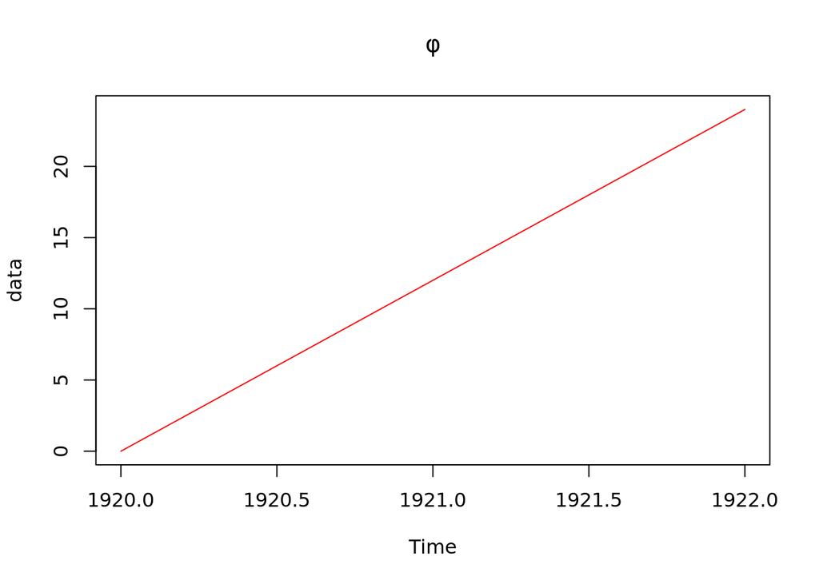

```r
# get data from library
milk <- subset(tsdl, 12, "Agriculture")[[3]]

# turn data into time series
data = data.frame("months"=0:24)
data = ts(data, start=1920, end = 1922, frequency=12)
ts.plot(data, main=TeX(r'($\phi$)'), col="red")
```

### Simulate and Plot ARMA Models

arima(x, order = c(p,d,q), seasonal = list(order = c(P,D,Q), period = S, fixed = c(phi_1.., theta_1…, Phi_1…, Theta_1…)))

- *Used for theoretical*
- *`x` a univariate time series*
- *`order` specification of the non-seasonal part of the ARIMA model (p,d,q)*
- *`seasonal` specification of seasonal part of the ARIMA model plus the period (P,D,Q) S*
- *`fixed` numeric vector of equal length to the coefficients of the sum of the orders of ar, ma, sar, and sma, where NA specifies coefficients to be estimated*

arima.sim(model, n, sd)

- *only useful to make a sample model for pure ARIMA*
- *`model` A list with component ar and/or ma giving the AR and MA coefficients respectively. Optionally a component order can be used. An empty list gives an ARIMA(0, 0, 0) model, that is white noise.*
- *`n` length of output series, before un-differencing. A strictly positive integer.*
- *`sd` standard deviation of the rand.gen*

auto.arima(y, d, D, max.p, max.q, max.P, max.Q, max.d, max.D, start.p, start.q, start.P, start.Q, stationary, seasonal, , allowmean, ic)

- *Used for theoretical*
- *Use to fit and estimate model coefficients and parameters using an existing time series*
- *`y` a univariate time series*
- *`d` Order of first-differencing. If missing, will choose a value based on test.*
- *`D` Order of seasonal-differencing. If missing, will choose a value based on season.test.*
- *`max.p` Maximum value of p*
- *`max.q` Maximum value of q*
- *`max.P` Maximum value of P*
- *`max.Q` Maximum value of Q*
- *`max.d` Maximum value of d*
- *`max.D` Maximum value of D*
- *`start.p` Starting value of p*
- *`start.q` Starting value of q*
- *`start.P` Starting value of P*
- *`start.Q` Starting value of Q*
- *`stationary` If TRUE, restricts search to stationary models.*
- *`seasonal` If FALSE, restricts search to non-seasonal models.*
- *`ic` Information criterion to be used in model selection. c(“aicc”, “aic”, “bic”)*
- *`allowmean` If TRUE, models with a non-zero mean are considered.*
- *`astsa::sarima` will provide more output values if parameters are known*

astsa::sarima(xdata, p, d, q, P, D, Q, S)

- *Used for theoretical*
- *`xdata` univariate time series*
- *`p` AR order (must be specified)*
- *`d` difference order (must be specified)*
- *`q` MA order (must be specified)*
- *`P` SAR order; use only for seasonal models*
- *`D` seasonal difference; use only for seasonal models*
- *`Q` SMA order; use only for seasonal models*
- *`S` seasonal period; use only for seasonal models*

sarima.for(n.ahead, *same as sarima*)

- *`n.ahead` forecast horizon (number of periods)*

sarima.sim(ar = NULL, d = 0, ma = NULL, sar = NULL, D = 0, sma = NULL, S = NULL, n = 500, rand.gen = rnorm, innov = NULL, burnin = NA)

- *`ar` coefficients of AR component (does not have to be specified)*
- *`d` order of regular difference (does not have to be specified)*
- *`ma` coefficients of MA component (does not have to be specified)*
- *`sar` coefficients of SAR component (does not have to be specified)*
- *`D` order of seasonal difference (does not have to be specified)*
- *`sma` coefficients of SMA component (does not have to be specified)*
- *`S` seasonal period (does not have to be specified)*
- *`n` desired sample size (defaults to 500)*
- *`rand.gen` optional; a function to generate the innovations (defaults to normal)*
- *`innov` an optional times series of innovations. If not provided, rand.gen is used.*
- *`burnin` length of burn-in (a non-negative integer). If NA (the default) a reasonable value is selected.*

sarima::sarima(model, data = NULL)

- *`model` a model formula specifying the model.*
- *`data` a list or data frame, usually can be omitted.*
  - *`ar(p)` autoregression term of order p*
  - *`ma(q)` moving average term of order q*
  - *`sar(s,p)` seasonal autoregression term (s seasons, order p)*
  - *`sma(s,q)` seasonal moving average term (s seasons, order q)*
  - *`i(d)` (1-B)^d*
  - *`si(d)` (1-B<sup>s)</sup>d*
  - *`s` seasonality*
- *For ar, ma, sar, sma, values of the coefficients can be specified by an unnamed argument after the parameters given in the descriptions above*
- *Argument `fixed` can be used to fix some of them. If it is a logical vector it should be of length one or have the same length as the coefficients*

```r
# auto.arima
auto_arima = auto.arima(milk, D=1, start.p = 0, start.q = 0, start.P = 0, start.Q = 0, seasonal = TRUE)

# sarima_sarima
# sarima::sarima(model = milk ~
#                  ar(1, c(auto_arima$coef[1])) + sar(12, 1, c(auto_arima$coef[2])) + s(12)| sma(12, 1, auto_arima$coef[3]))

# arima
# need to check to see what is wrong
arima = arima(milk, order=c(1,0,0), seasonal = list(order = c(1,1,1), period=12), fixed = c(auto_arima$coef[1], auto_arima$coef[2], auto_arima$coef[3]), include.mean=TRUE, transform.pars=TRUE)

# sim_sarima
sim_sarima = sim_sarima(model = list(ar=auto_arima$coef[1],  sar=auto_arima$coef[3], sma=auto_arima$coef[2], siorder=1, nseasons=12), n=156, x = milk, n.start=1)

# astsa::sarima
astsa_sarima = astsa::sarima(milk, 1,0,0,1,1,1,12, Model = TRUE)
```

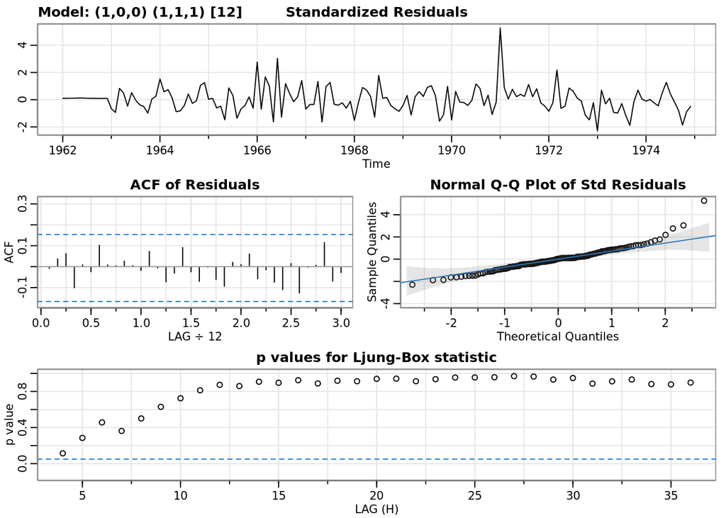

```r
# Check if methods have same result
unique(astsa_sarima$fit$residuals == auto_arima$residuals)
```

```
## [1] TRUE
```

```r
unique(astsa_sarima$fit$residuals == arima$residuals)
```

```
## [1] FALSE
```